# PredictionAssignment

mansipriya

September 18, 2018

Using devices such as Jawbone Up, Nike FuelBand, and Fitbit it is now possible to collect a large amount of data about personal activity relatively inexpensively. These type of devices are part of the quantified self movement - a group of enthusiasts who take measurements about themselves regularly to improve their health, to find patterns in their behavior, or because they are tech geeks. One thing that people regularly do is quantify how much of a particular activity they do, but they rarely quantify how well they do it. In this project, my goal will be to use data from accelerometers on the belt, forearm, arm, and dumbell of 6 participants. They were asked to perform barbell lifts correctly and incorrectly in 5 different ways. More information is available from the website here: http://groupware.les.inf.puc-rio.br/har (see the section on the Weight Lifting Exercise Dataset)

### Getting the data

```r
training_url <- "http://d396qusza40orc.cloudfront.net/predmachlearn/pml-training.csv"
test_url <- "http://d396qusza40orc.cloudfront.net/predmachlearn/pml-testing.csv"
training <- read.csv(url(training_url))
test <- read.csv(url(test_url))
```

### Analyzing the data

```r
dim(training)
```

```
## [1] 19622   160
```

```r
head(training)
```

```
##   X user_name raw_timestamp_part_1 raw_timestamp_part_2   cvtd_timestamp
## 1 1  carlitos           1323084231               788290 05/12/2011 11:23
## 2 2  carlitos           1323084231               808298 05/12/2011 11:23
## 3 3  carlitos           1323084231               820366 05/12/2011 11:23
## 4 4  carlitos           1323084232               120339 05/12/2011 11:23
## 5 5  carlitos           1323084232               196328 05/12/2011 11:23
## 6 6  carlitos           1323084232               304277 05/12/2011 11:23
##   new_window num_window roll_belt pitch_belt yaw_belt total_accel_belt
## 1         no         11      1.41       8.07    -94.4                3
## 2         no         11      1.41       8.07    -94.4                3
## 3         no         11      1.42       8.07    -94.4                3
## 4         no         12      1.48       8.05    -94.4                3
## 5         no         12      1.48       8.07    -94.4                3
## 6         no         12      1.45       8.06    -94.4                3
##   kurtosis_roll_belt kurtosis_picth_belt kurtosis_yaw_belt
```

[output cut: 265 more lines]

```r
dim(test)
```

```
## [1]  20 160
```

```r
head(test)
```

```
##   X user_name raw_timestamp_part_1 raw_timestamp_part_2   cvtd_timestamp
## 1 1     pedro           1323095002               868349 05/12/2011 14:23
## 2 2    jeremy           1322673067               778725 30/11/2011 17:11
## 3 3    jeremy           1322673075               342967 30/11/2011 17:11
## 4 4    adelmo           1322832789               560311 02/12/2011 13:33
## 5 5    eurico           1322489635               814776 28/11/2011 14:13
## 6 6    jeremy           1322673149               510661 30/11/2011 17:12
##   new_window num_window roll_belt pitch_belt yaw_belt total_accel_belt
## 1         no         74    123.00      27.00    -4.75               20
## 2         no        431      1.02       4.87   -88.90                4
## 3         no        439      0.87       1.82   -88.50                5
## 4         no        194    125.00     -41.60   162.00               17
## 5         no        235      1.35       3.33   -88.60                3
## 6         no        504     -5.92       1.59   -87.70                4
##   kurtosis_roll_belt kurtosis_picth_belt kurtosis_yaw_belt
```

[output cut: 265 more lines]

We can see lot of NAs are present in the dataset. Lets first remove that

```r
training <- training[, colSums(is.na(training)) == 0]
test <- test[, colSums(is.na(test)) == 0]
## Removing unnecessary data
classe<- training$classe
trainRemove<- grepl("^X|timestamp|window", names(training))
training<- training[, !trainRemove]
training<- training[, sapply(training, is.numeric)]
training$classe <- classe
testRemove<- grepl("^X|timestamp|window", names(test))
test<- test[, !testRemove]
test<- test[, sapply(test, is.numeric)]
```

### Explopratory Data Analysis

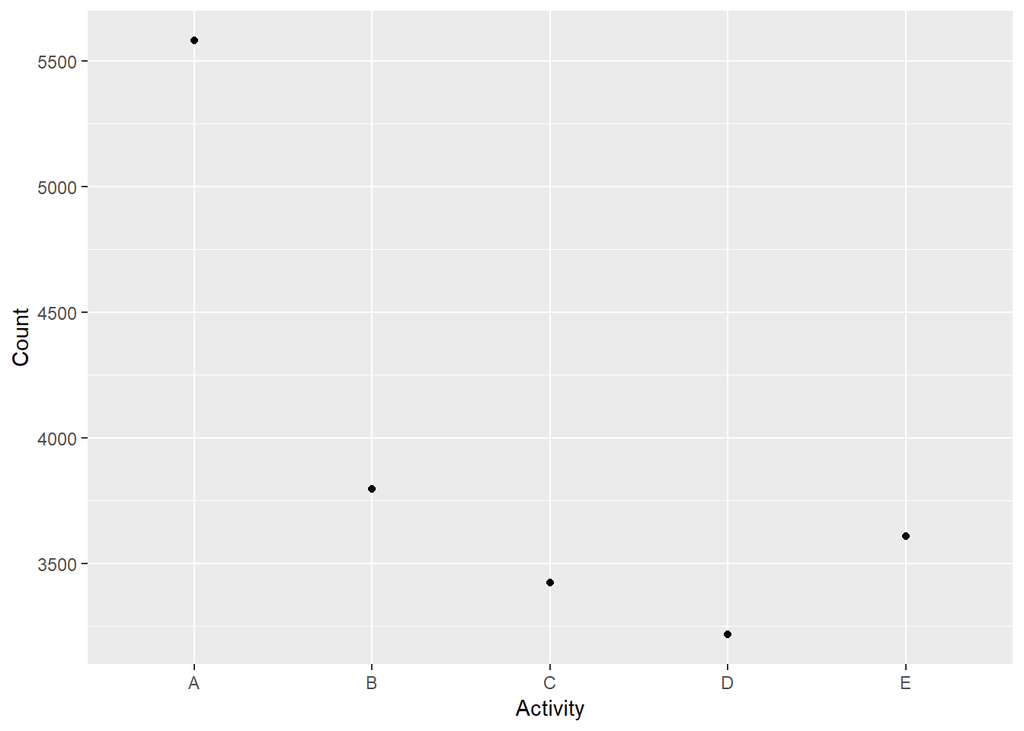

```r
class_table <- data.frame(table(training$classe))
library(ggplot2)
qplot(x = class_table$Var1, y = class_table$Freq,data = class_table, geom = "point", xlab = "Activity", ylab = "Count")
```

We can see Activity A is the most Frequent activity done by people

Now lets create training and test set

```r
library(caret)
set.seed(12345)
inTrain <- createDataPartition(training$classe, p=0.70, list=F)
train_data <- training[inTrain, ]
test_data <- training[-inTrain, ]
```

### Model Training

```r
## Lets firt try decision tree
fit1 <- train(classe~.,data = train_data, method = "rpart")
library(rattle)
```

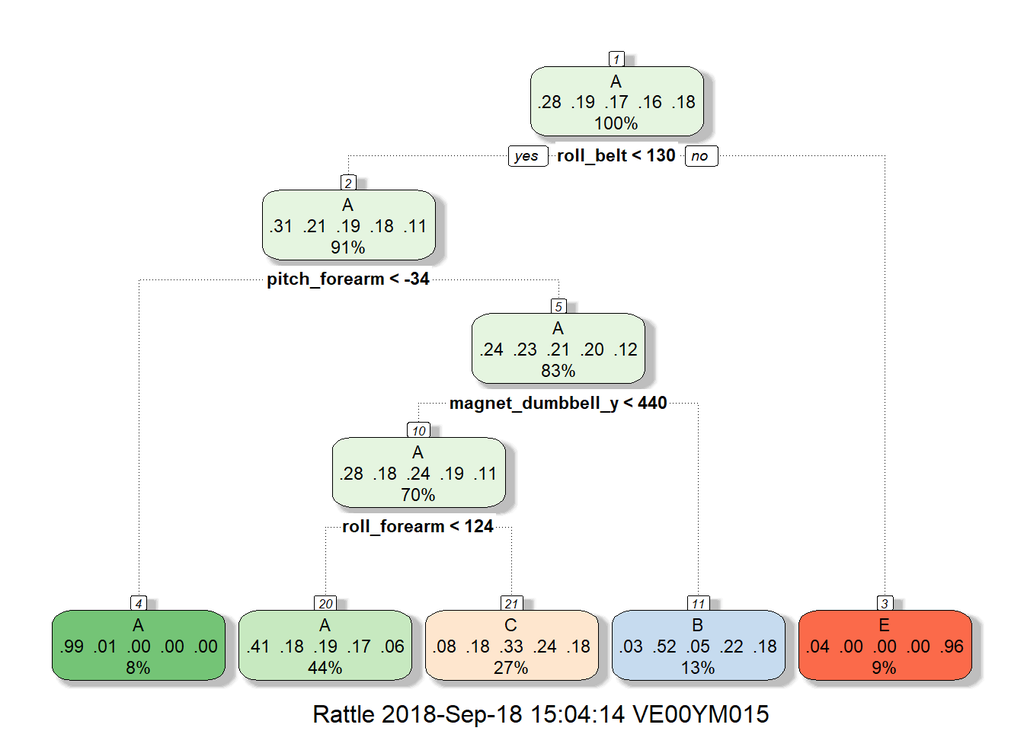

```r
fancyRpartPlot(fit1$finalModel)
```

Lets check accuracy of this model

```r
pred <- predict(fit1,test_data)
confusionMatrix(test_data$classe , pred)
```

```
## Confusion Matrix and Statistics
##
##           Reference
## Prediction    A    B    C    D    E
##          A 1494   21  128    0   31
##          B  470  380  289    0    0
##          C  467   29  530    0    0
##          D  438  184  342    0    0
##          E  141  147  277    0  517
##
## Overall Statistics
##
##                Accuracy : 0.4963
##                  95% CI : (0.4835, 0.5092)
##     No Information Rate : 0.5115
##     P-Value [Acc > NIR] : 0.9902
##
##                   Kappa : 0.3425
##  Mcnemar's Test P-Value : NA
##
## Statistics by Class:
##
##                      Class: A Class: B Class: C Class: D Class: E
## Sensitivity            0.4963  0.49934  0.33844       NA  0.94343
## Specificity            0.9374  0.85187  0.88516   0.8362  0.89414
## Pos Pred Value         0.8925  0.33363  0.51657       NA  0.47782
## Neg Pred Value         0.6400  0.91972  0.78679       NA  0.99355
## Prevalence             0.5115  0.12931  0.26610   0.0000  0.09312
## Detection Rate         0.2539  0.06457  0.09006   0.0000  0.08785
## Detection Prevalence   0.2845  0.19354  0.17434   0.1638  0.18386
## Balanced Accuracy      0.7169  0.67561  0.61180       NA  0.91878
```

As we can see accuracy is quite low. lets try with another model

```r
fit2 <- train(classe ~., data=train_data, method="rf",  trControl=trainControl(method="cv", 5), ntree=100)
pred <- predict(fit2,test_data)
confusionMatrix(test_data$classe , pred)
```

```
## Confusion Matrix and Statistics
##
##           Reference
## Prediction    A    B    C    D    E
##          A 1673    1    0    0    0
##          B   13 1118    8    0    0
##          C    0   16 1006    4    0
##          D    0    0   26  938    0
##          E    0    0    2    4 1076
##
## Overall Statistics
##
##                Accuracy : 0.9874
##                  95% CI : (0.9842, 0.9901)
##     No Information Rate : 0.2865
##     P-Value [Acc > NIR] : < 2.2e-16
##
##                   Kappa : 0.9841
##  Mcnemar's Test P-Value : NA
##
## Statistics by Class:
##
##                      Class: A Class: B Class: C Class: D Class: E
## Sensitivity            0.9923   0.9850   0.9655   0.9915   1.0000
## Specificity            0.9998   0.9956   0.9959   0.9947   0.9988
## Pos Pred Value         0.9994   0.9816   0.9805   0.9730   0.9945
## Neg Pred Value         0.9969   0.9964   0.9926   0.9984   1.0000
## Prevalence             0.2865   0.1929   0.1771   0.1607   0.1828
## Detection Rate         0.2843   0.1900   0.1709   0.1594   0.1828
## Detection Prevalence   0.2845   0.1935   0.1743   0.1638   0.1839
## Balanced Accuracy      0.9960   0.9903   0.9807   0.9931   0.9994
```

In this model we get accuracy around 99%. Hence this model is a good one to rely on for predictions.

## Predicting for test data

```r
test_pred <- predict(fit2 , test)
test_pred
```

```
##  [1] B A B A A E D B A A B C B A E E A B B B
## Levels: A B C D E
```